# Homework 06

Joe Dickerson

2025-02-28

```r
## packages
library(faraway)
library(tidyverse)
library(nnet)
library(MASS)
```

The pneumo data gives the number of coal miners classified by radiological examination into one of three categories of pneumonoconiosis and by the number of years spent working at the coal face divided into eight categories.

1. Make a plot showing how the proportion on miners in the three categories at each year point varies over time. Comment on the relationship.

As we might expect from presumptions, we see the proportion of pneumonoconiosis increase as years of service increases. Likewise, we see normal proportion decrease.

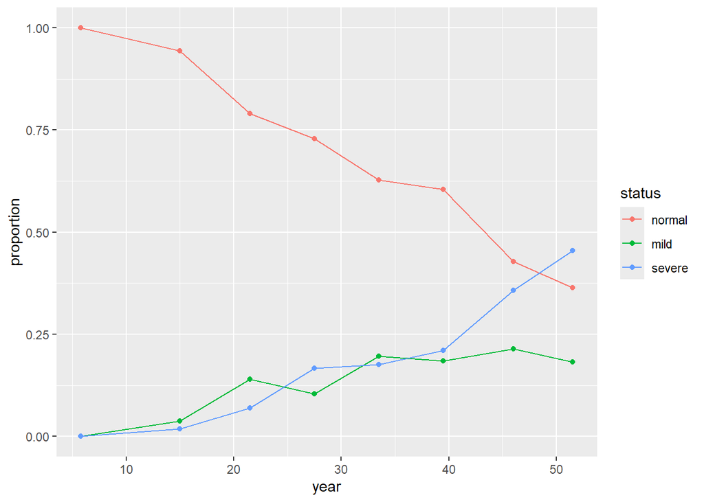

```r
data(pneumo)

pneumo_sum <- pneumo %>%
  group_by(year, status) %>%
  summarise(count = sum(Freq), .groups = "drop") %>%
  group_by(year) %>%
  mutate(tot_count = sum(count),
         proportion = count / tot_count,
         status = factor(status, levels = c("normal", "mild", "severe")))

pneumo_sum %>%
  ggplot(aes(x = year, y = proportion, color = status)) +
  geom_point() +
  geom_line()
```

2. Treating the pneumonoconiosis status as response variable as nominal, build a model for predicting the frequency of the three outcomes in terms of length of service. What does the model say about the similarity of the proportions falling into the mild and severe categories?

Per the model, it appears that we expect a the log-odds of mild status to increase 0.0837 each year of service, while we expect the log odds of severe status to increase by 0.1093 for each year of service. At 0 years of service, the log-odds of being a mild case is -4.292, while the log-odds of being a severe case is -5.0598.

```r
mmod <- multinom(status ~ year, data = pneumo_sum, weights = count)
summary(mmod)
```

```
## Call:
## multinom(formula = status ~ year, data = pneumo_sum, weights = count)
##
## Coefficients:
##        (Intercept)       year
## mild     -4.291680 0.08356529
## severe   -5.059849 0.10928549
##
## Std. Errors:
##        (Intercept)       year
## mild     0.5214120 0.01528046
## severe   0.5964319 0.01646978
##
## Residual Deviance: 417.4496
## AIC: 425.4496
```

3. Would it be better to use log(year) as the predictor?

We have a slightly lower deviance so it seems log(year) fits the model slightly better. However, it is possible that changing the scale would decrease interpretability of the data.

```r
mmodLog <- multinom(status ~ log(year), data = pneumo_sum, weights = count)
summary(mmodLog)
```

```
## Call:
## multinom(formula = status ~ log(year), data = pneumo_sum, weights = count)
##
## Coefficients:
##        (Intercept) log(year)
## mild     -8.936034  2.165374
## severe  -11.975104  3.067470
##
## Std. Errors:
##        (Intercept) log(year)
## mild      1.580439 0.4574870
## severe    2.000447 0.5652072
##
## Residual Deviance: 408.8689
## AIC: 416.8689
```

4. Produce a plot of the predicted probabilities in the same format as (a).

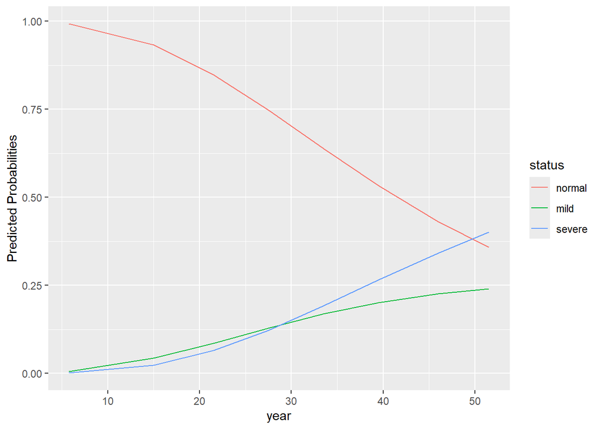

```r
mmodPred <- predict(mmodLog, type = "probs")

pneumo_long <- cbind(pneumo_sum, mmodPred) %>%
  gather(key = "status", value = "pred_long", normal, mild, severe) %>%
  mutate(status = factor(status, levels = c("normal", "mild", "severe")))

pneumo_long %>%
  ggplot(aes(x = year, y = pred_long, color = status)) +
  geom_line() +
  labs(y = "Predicted Probabilities")
```

5. Fit a proportional odds model to the data. Take care to order response correctly. You will need to specify the number falling in each case using the weight argument. What is the estimated value of θ1 and how should it be interpreted?

The zeta value of 9.676 represents the log odds threshold that someone is more likely to fall into the mild category than normal.

```r
pneumo_ordered <- pneumo_sum %>%
  mutate(status_ordered = factor(status, levels = c("normal", "mild", "severe"), ordered = TRUE))

pomod <- polr(status ~ log(year), data = pneumo_sum, weights = count)

pomod$zeta
```

```
## normal|mild mild|severe
##    9.676327   10.581962
```

7. Extract the predicted probabilities from the model and plot in the same format as (a). Compare to the predictions from the nominal model.

We have a very similar plot, though it appears that mild and severe are more closely linked in the proportional-odds model, though not by much.

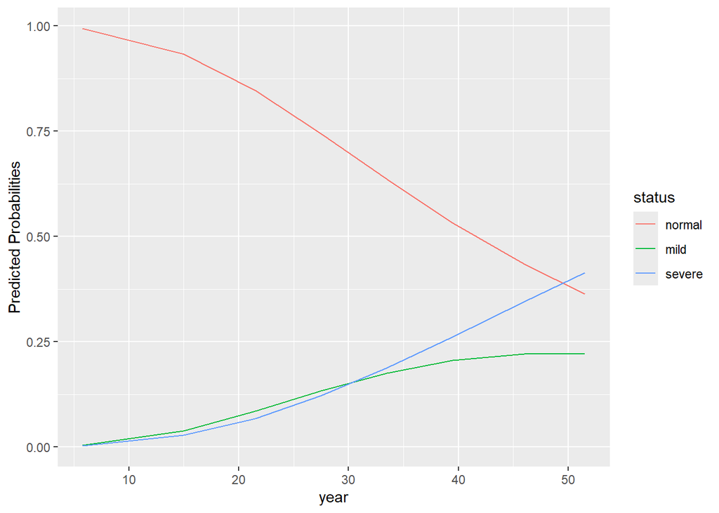

```r
pomodPred <- predict(pomod, type = "probs")

pomod_long <- cbind(pneumo_sum, pomodPred) %>%
  gather(key = "status", value = "pomod_long", normal, mild, severe) %>%
  mutate(status = factor(status, levels = c("normal", "mild", "severe")))

pomod_long %>%
  ggplot(aes(x = year, y = pomod_long, color = status)) +
  geom_line() +
  labs(y = "Predicted Probabilities")
```

8. Fit a hierarchical model to the status response. First fit a binomial response normal and not normal. Interpret the effect of year on the odds of getting the lung disease.

It appears there is a strong effect on year and the odds of getting penumonoconiosis. We have a very small p-value. However, our deviance is rather high for our degrees of freedom. Our AIC is also very high.

```r
df <- pneumo %>%
  mutate(normal = ifelse(status == "normal", Freq, 0),
         mild = ifelse(status == "mild", Freq, 0),
         severe = ifelse(status == "severe", Freq, 0),
         notnormal = ifelse(status == "normal", 0, mild + severe))


bmod1 <- glm(cbind(normal, notnormal) ~ year, df, family = "binomial")

summary(bmod1)
```

```
##
## Call:
## glm(formula = cbind(normal, notnormal) ~ year, family = "binomial",
##     data = df)
##
## Coefficients:
##             Estimate Std. Error z value Pr(>|z|)
## (Intercept)  3.96635    0.41891   9.468  < 2e-16 ***
## year        -0.09627    0.01236  -7.787 6.88e-15 ***
## ---
## Signif. codes:  0 '***' 0.001 '**' 0.01 '*' 0.05 '.' 0.1 ' ' 1
##
## (Dispersion parameter for binomial family taken to be 1)
##
##     Null deviance: 391.93  on 21  degrees of freedom
## Residual deviance: 305.93  on 20  degrees of freedom
## AIC: 309.93
##
## Number of Fisher Scoring iterations: 5
```

1. Now fit a binomial model for mild vs. severe lung disease. Is the year effect significant. What is the probability of a mild disease within the diseased sub group?

The year effect does not appear significant in this model, which seems to indicate that the probability of mild and severe are similar with respect to one another.

```r
bmod2 <- glm(cbind(mild, severe) ~ year, df, family = "binomial")

summary(bmod2)
```

```
##
## Call:
## glm(formula = cbind(mild, severe) ~ year, family = "binomial",
##     data = df)
##
## Coefficients:
##             Estimate Std. Error z value Pr(>|z|)
## (Intercept)  1.11342    0.86248   1.291    0.197
## year        -0.03547    0.02350  -1.509    0.131
##
## (Dispersion parameter for binomial family taken to be 1)
##
##     Null deviance: 113.24  on 13  degrees of freedom
## Residual deviance: 110.89  on 12  degrees of freedom
## AIC: 114.89
##
## Number of Fisher Scoring iterations: 3
```

10. Compute the predicted probabilities of the three categories by combining the two binomial model predictions. Plot in the same format as (a) and comment.

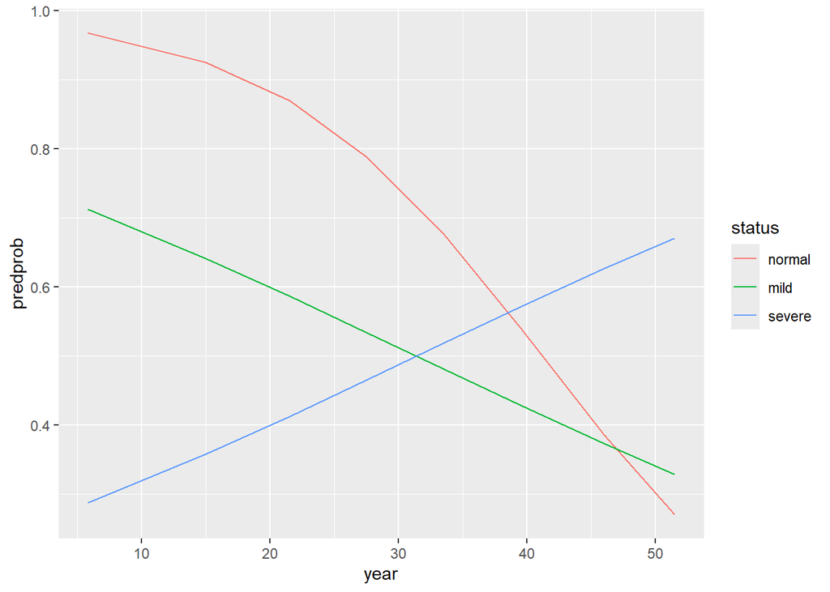

```r
predbmod1 <- predict(bmod1, type = "response")
predbmod2 <- predict(bmod2, type = "response")

predcombined <- df %>%
  mutate(
    normalprob = predbmod1,
    notnormalprob = 1 - predbmod1,
    mildprob = predbmod2,
    severeprob = 1 - predbmod2
  )

predlong <- predcombined %>%
  gather(key = "status", value = "predprob", normalprob, mildprob, severeprob) %>%
  mutate(status = factor(status, levels = c("normalprob", "mildprob", "severeprob"),
                         labels = c("normal", "mild", "severe")))

ggplot(predlong, aes(x = year, y = predprob, color = status)) +
  geom_line()
```